# Python3

## Intro To Python part 3

### removing items from a list and other details

```python
my_list = ["sunny","cloudy","rainy","windy"]
print(my_list)
```

```
['sunny', 'cloudy', 'rainy', 'windy']
```

```python
del my_list[0]
print(my_list)
```

```
['cloudy', 'rainy', 'windy']
```

```python
my_list.remove("cloudy")
print(my_list)
```

```
['rainy', 'windy']
```

## Functions

```python
# this is how you define a function
def add_item(input_list, thing):
   """
   add_item appends an item to a list.
   To call it, pass in the list and the item to be added.
   """
   input_list.append(thing);
   return
```

```python
#add_item??
#help(add_item)
```

```python
whos
```

```
Variable   Type        Data/Info
--------------------------------
add_item   function    <function add_item at 0x104146488>
my_list    list        n=2
```

```python
my_list = ["sunny","cloudy","rainy","windy"]
add_item(my_list, 5)
print(my_list)
```

```
['sunny', 'cloudy', 'rainy', 'windy', 5]
```

```python
whos
```

```
Variable   Type        Data/Info
--------------------------------
add_item   function    <function add_item at 0x104146488>
my_list    list        n=5
```

```python
add_item(my_list, "blue")
print(my_list)
```

```
['sunny', 'cloudy', 'rainy', 'windy', 5, 'blue']
```

```python
#has to be in order
add_item("green", my_list)
print(my_list)
```

```
---------------------------------------------------------------------------
AttributeError                            Traceback (most recent call last)
<ipython-input-10-aece336b8467> in <module>()
      1 #has to be in order
----> 2 add_item("green", my_list)
      3 print(my_list)

<ipython-input-4-f6ce62d96c53> in add_item(input_list, thing)
      5    To call it, pass in the list and the item to be added.
      6    """
----> 7    input_list.append(thing);
      8    return

AttributeError: 'str' object has no attribute 'append'
```

```python
# can call a function in a loop
my_list = ["sunny","cloudy","rainy","windy"]
my_other_list=["green", "yellow", "red"]

for thing in my_other_list:   #<--- a few words about naming
    add_item(my_list, thing)
print(my_list)
```

```
['sunny', 'cloudy', 'rainy', 'windy', 'green', 'yellow', 'red']
```

```python
# the easier way to do that
my_list = ["sunny","cloudy","rainy","windy"]
my_other_list=["green", "yellow", "red"]
yet_another_list = my_list + my_other_list
print(yet_another_list)
```

```
['sunny', 'cloudy', 'rainy', 'windy', 'green', 'yellow', 'red']
```

### Namespace

```python
import this
```

```
The Zen of Python, by Tim Peters

Beautiful is better than ugly.
Explicit is better than implicit.
Simple is better than complex.
Complex is better than complicated.
Flat is better than nested.
Sparse is better than dense.
Readability counts.
Special cases aren't special enough to break the rules.
Although practicality beats purity.
Errors should never pass silently.
Unless explicitly silenced.
In the face of ambiguity, refuse the temptation to guess.
There should be one-- and preferably only one --obvious way to do it.
Although that way may not be obvious at first unless you're Dutch.
Now is better than never.
Although never is often better than *right* now.
If the implementation is hard to explain, it's a bad idea.
If the implementation is easy to explain, it may be a good idea.
Namespaces are one honking great idea -- let's do more of those!
```

```python
# namespace
def add_em():
    print(announce)
    print(a+b)
    return
```

```python
#namespace example
announce="I have your result:"
a=1
b=2

add_em()
```

```
I have your result:
3
```

```python
# namespace
def add_em():
    a=5 # <-------
    b=6 # <-------
    print(announce)
    print(a+b)
    return
```

```python
# namespace
def add_em(a,b):# <-------  and edit the call to include the parameters
    print(announce)
    print(a+b)
    return
```

### Parameters pass by Reference

```python
def fillCup(cup):
    "Sets the parameter to 'full'"
    cup="full"
    print(cup)
    return
```

```python
cup="empty"
fillCup(cup)
print(cup)
```

```
full
empty
```

#### Any time you see varname =, you're creating a new name binding within the function's scope. Whatever value varname was bound to before is lost within this scope.

#### Any time you see varname.foo() you're calling a method on varname. The method may alter varname (e.g. list.append). varname (or, rather, the object that varname names) may exist in more than one scope, and since it's the same object, any changes will be visible in all scopes.

### Another way to do it

```python
def fillCup2(cup):
    "Sets the parameter to 'full'"
    return("full")
```

```python
cup="empty"
print(cup)
cup=fillCup2(cup)
print(cup)
```

```
empty
full
```

## Objects with classes

### for filling cups, this might be better

```python
class cup:
    """An object with .state, .color and .temp"""
    state = "empty"
    color = "brown"
    temp = 110

    #def fill():
        #cup.state = "full"
```

```python
print(cup.__doc__)
#print(add_item.__doc__)
```

```
An object with .state, .color and .temp
```

```python
my_cup = cup
print(my_cup.state)
print(my_cup.color)
print(my_cup.temp)
```

```
empty
brown
110
```

```python
def fill_cup(a_cup):
    a_cup.state = "full"
    return
```

```python
print(my_cup.state)
fill_cup(my_cup)
print(my_cup.state)
```

```
empty
full
```

```python
#add this method to cup:
class cup:
    """An object with .name, .state, .color, .temp ()"""

    def __init__(self, name, color):
        self.state = "empty"
        self.color = color
        self.name = name
        self.temp = 72

    def fill(self):
        if (self.state == "empty"):
            self.state = "full"
            self.temp = self.temp + 50
        return

    def drain(self):
        if (self.state == "full"):
            self.state = "empty"
            self.temp = self.temp - 50
        return
```

```python
print(cup.__doc__)
```

```
An object with .name, .state, .color, .temp ()
```

```python
help(cup)
```

```
Help on class cup in module __main__:

class cup(builtins.object)
 |  An object with .name, .state, .color, .temp ()
 |  Methods defined here:
 |  __init__(self, name, color)
 |      Initialize self.  See help(type(self)) for accurate signature.
 |  drain(self)
 |  fill(self)
 |  ----------------------------------------------------------------------
 |  Data descriptors defined here:
 |  __dict__
 |      dictionary for instance variables (if defined)
 |  __weakref__
 |      list of weak references to the object (if defined)
```

```python
my_cup = cup("Janna's favorite mug", "green")

print(my_cup.name)
print(my_cup.color)
print(my_cup.temp)
print(my_cup.state)
```

```
Janna's favorite mug
green
72
empty
```

```python
my_cup.fill()
print(my_cup.state)
print(my_cup.temp)
```

```
full
122
```

```python
your_cup = cup("Alper's ALPER mug", "black")

your_cup.drain()
print(your_cup.name)
print(your_cup.color)
print(your_cup.temp)
print(your_cup.state)
```

```
Alper's ALPER mug
black
72
empty
```

```python
def print_cup(the_cup):
    print(the_cup.name)
    print(the_cup.state)
    print(the_cup.color)
    print(the_cup.temp)
    print("")
    return
```

```python
print_cup(my_cup)
print_cup(your_cup)
```

```
Janna's favorite mug
full
green
122

Alper's ALPER mug
empty
black
72
```

```python
cups=[my_cup, your_cup]
for mug in cups:
    print_cup(mug)
```

```
Janna's favorite mug
full
green
122

Alper's ALPER mug
empty
black
72
```

```python
def coffee_for_friends(a_list):
    for cup in a_list:
        cup.fill()
```

```python
coffee_for_friends(cups)
for mug in cups:
    print_cup(mug)
```

```
Janna's favorite mug
full
green
122

Alper's ALPER mug
full
black
122
```

## Packages (also called Libraries)

```python
!pwd  #<-- "!" lets you run commands in the terminal
```

```
/Users/jnugent
```

```python
!pip install numpy
```

```
You are using pip version 8.1.2, however version 9.0.1 is available.
```

```python
import numpy as np
```

```python
np??  #<--- going to look at "random", a module in the package
```

```
  File "<ipython-input-41-d599f84c3c67>", line 1
    np??  #<--- going to look at "random", a module in the package
      ^
SyntaxError: invalid syntax
```

```python
help(np.random)  #<--- looking for "shuffle"
```

```python
help(np.random.shuffle)  #<--- what syntax do we use? (example)
```

```python
help(range)
```

```python
my_list = list(range(0, 10))
print(my_list)
```

```python
np.random.shuffle(my_list)
print(my_list)
```

### Overloading functions

```python
stringy = "Hello"
print(stringy)
print(len(stringy))
```

```python
def len(input_string):
    output_string = input_string + ", how's it going?"
    print(output_string)
    return
```

```python
len(stringy)
```

```
---------------------------------------------------------------------------
NameError                                 Traceback (most recent call last)
<ipython-input-43-b27fb4bb2215> in <module>()
----> 1 len(stringy)

NameError: name 'stringy' is not defined
```

```python
whos
```

```
Variable             Type        Data/Info
------------------------------------------
a                    int         1
add_em               function    <function add_em at 0x104173ea0>
add_item             function    <function add_item at 0x104146488>
announce             str         I have your result:
b                    int         2
coffee_for_friends   function    <function coffee_for_friends at 0x104173d90>
cup                  type        <class '__main__.cup'>
cups                 list        n=2
fillCup              function    <function fillCup at 0x10417c158>
fillCup2             function    <function fillCup2 at 0x10417c268>
fill_cup             function    <function fill_cup at 0x10417c510>
len                  function    <function len at 0x1093cc730>
mug                  cup         <__main__.cup object at 0x10417f358>
my_cup               cup         <__main__.cup object at 0x1041f8048>
my_list              list        n=4
my_other_list        list        n=3
np                   module      <module 'numpy' from '/Us<...>kages/numpy/__init__.py'>
print_cup            function    <function print_cup at 0x10417cf28>
thing                str         red
this                 module      <module 'this' from '/Use<...>3/lib/python3.5/this.py'>
yet_another_list     list        n=7
your_cup             cup         <__main__.cup object at 0x10417f358>
```

### You can't unload functions in python -> to clear these values, go up to the "kernel" menu and select "Restart"

```python
whos
```

```
Variable             Type        Data/Info
------------------------------------------
a                    int         1
add_em               function    <function add_em at 0x104173ea0>
add_item             function    <function add_item at 0x104146488>
announce             str         I have your result:
b                    int         2
coffee_for_friends   function    <function coffee_for_friends at 0x104173d90>
cup                  type        <class '__main__.cup'>
cups                 list        n=2
fillCup              function    <function fillCup at 0x10417c158>
fillCup2             function    <function fillCup2 at 0x10417c268>
fill_cup             function    <function fill_cup at 0x10417c510>
len                  function    <function len at 0x1093cc730>
mug                  cup         <__main__.cup object at 0x10417f358>
my_cup               cup         <__main__.cup object at 0x1041f8048>
my_list              list        n=4
my_other_list        list        n=3
np                   module      <module 'numpy' from '/Us<...>kages/numpy/__init__.py'>
print_cup            function    <function print_cup at 0x10417cf28>
thing                str         red
this                 module      <module 'this' from '/Use<...>3/lib/python3.5/this.py'>
yet_another_list     list        n=7
your_cup             cup         <__main__.cup object at 0x10417f358>
```

## Exercises

1) Write a function that returns the absolute value of one number minus a second number. Call it twice from another Jupyter cell, switching the order of the two numbers that you pass to the function, and write an if/else statement that prints out if the two values return by the function are equal.

```python
# Example solution:

def num_between(a,b):
    difference = abs(a - b)    #<-- students may have to look this up
    return(difference)
```

```python
a = 3
b = 7
diff_ab = num_between(a,b)
diff_ba = num_between(b,a)
if diff_ab == diff_ba:
    print("the function is correct, the values are equal")
else:
    print("the function is in error, the values aren't equal")
```

```
the function is correct, the values are equal
```

2) Write a function that takes a list of six words and prints every other word in all caps.

```python
# Example solution:

def cap_every_other(my_list):
    counter=0
    for word in my_list:
        if counter%2==0:
            print(word.upper())
        else:
            print(word)
        counter = counter+1
    return
```

```python
words = ("yellow", "green", "blue", "orange", "white", "black")
cap_every_other(words)
```

```
YELLOW
green
BLUE
orange
WHITE
black
```

3) copy your code for the above exercise and modify it so the function creates a returns a new, second list into a new list variable which has every other word capitalized.

```python
# Example solution for 3):

def cap_every_other_new(my_list):
    new_list=[]
    counter=0
    for word in my_list:
        if counter%2==0:
            new_list.append(word.upper())
        else:
            new_list.append(word)
        counter = counter+1
    return(new_list)
```

```python
words = ["January", "February", "April", "May", "June", "July"]
better_words = cap_every_other_new(words)
print(better_words)
```

```
['JANUARY', 'February', 'APRIL', 'May', 'JUNE', 'July']
```

```python
#solution 4)

def rem_big_words(my_list):
    remove_these=[]
    for word in my_list:
        if (len(word)> 5):
            remove_these.append(word)
    for word in remove_these:
        my_list.remove(word)
    #print(my_list)
    return(remove_these)
```

```python
months = ["January", "February", "April", "May", "June", "July"]
short_months=rem_big_words(months)
print(months)
print(short_months)
```

```
['April', 'May', 'June', 'July']
['January', 'February']
```

5) Write a Python function that takes a list and returns a new list with unique elements of the first list.

```python
def uniq_list(my_list):
  unique_list = []
  for thing in my_list:
    if thing not in unique_list:
      unique_list.append(thing)
  return unique_list
```

```python
dup_list = [1,1,3,4,4,6,1,5,1,4,4,2]
unique = uniq_list(dup_list)
print(unique)
```

```
[1, 3, 4, 6, 5, 2]
```

6) Write a function to reverse a string

```python
#6) solution
def string_reverse(stringy):
    reversed_string = ''
    index = len(stringy)
    while index > 0:
        reversed_string += stringy[ index - 1 ]
        index = index - 1
    return reversed_string
```

```python
print(string_reverse('Janna'))
```

```
annaJ
```

7) Write a function to create and print a list where the values are square of numbers between 1 and 15

```python
#7) solution
def printValues():
    squares_list = list()
    for num in range(1,16):
        squares_list.append(num**2)
    print(squares_list)

printValues()
```

```
[1, 4, 9, 16, 25, 36, 49, 64, 81, 100, 121, 144, 169, 196, 225]
```

8) import the library called "numpy". Use help to figure out how to reimpliment your solution to 7) but getting square roots instead of squaring, using the numpy library (hint: use help(np))

```python
import numpy as np

def printValues():
    squares_list = list()
    for num in range(1,16):
        squares_list.append(np.sqrt(num))
    print(squares_list)

printValues()
```

```
[1.0, 1.4142135623730951, 1.7320508075688772, 2.0, 2.2360679774997898, 2.4494897427831779, 2.6457513110645907, 2.8284271247461903, 3.0, 3.1622776601683795, 3.3166247903553998, 3.4641016151377544, 3.6055512754639891, 3.7416573867739413, 3.872983346207417]
```

9) create a class called grad_student. Give your grad_students the attributes "name", "year", "school", and "advisor". Write methods for things graduate students do, for example a .graduate() method that might change the grad_student name to include "PhD" at the end of it. Write a function to print out the status of grad_students. Create three grad_students and print their values out. Pick one and let them graduate, then print their values out again to confirm the name change.

```python
class grad_student:
    """An object with .name, .year, .school, .advisor ()"""

    def __init__(self, name, year, school, advisor):
        self.name = name
        self.year = year
        self.school = school
        self.advisor = advisor

    def graduate(self):
        degree = "PhD"
        new_name = self.name + ", " + degree
        self.name = new_name
        self.advisor = new_name
        self.year = '-'
        return
```

```python
chad = grad_student("Chad", 3, "Feinberg", "Prof. Einsten")
shiva = grad_student("Shiva", 5, "Weinberg", "Prof. Degrasse Tyson")
```

```python
def print_student(student):
    print(student.name)
    print("year", student.year)
    print(student.school)
    print(student.advisor)
    print("")
```

```python
print_student(chad)
print_student(shiva)
```

```
Chad
year 3
Feinberg
Prof. Einsten

Shiva
year 5
Weinberg
Prof. Degrasse Tyson
```

```python
shiva.graduate()
print_student(shiva)
```

```
Shiva, PhD
year -
Weinberg
Shiva, PhD
```

10) Use the package matplotlib. import matplotlib.pyplot as plt. To allow you to display graphs in Jupyter notebooks, after the import on a line by itself type "%matplotlib inline". Use help(plt.plot) to help you make a basic plot. (remember to look for the "examples"). Google "pyplot tutorial" and click on the top link; copy some of the examples into your Jupyter notebook and run them.

```python
import matplotlib.pyplot as plt
%matplotlib inline
```

```python
help(plt.plot)
```

[output not shown]

[output cut: 128 more lines]

[output not shown]

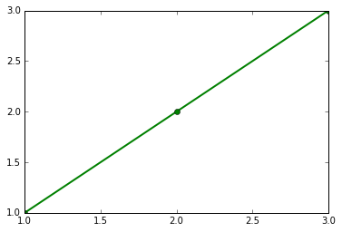

```python
plt.plot([1,2,3], [1,2,3], 'go-', label='line 1', linewidth=2)
```

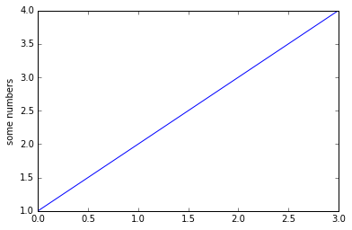

```python
plt.plot([1,2,3,4])
plt.ylabel('some numbers')
plt.show()
```

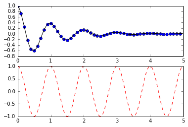

```python
import numpy as np
import matplotlib.pyplot as plt

def f(t):
    return np.exp(-t) * np.cos(2*np.pi*t)

t1 = np.arange(0.0, 5.0, 0.1)
t2 = np.arange(0.0, 5.0, 0.02)

plt.figure(1)
plt.subplot(211)
plt.plot(t1, f(t1), 'bo', t2, f(t2), 'k')

plt.subplot(212)
plt.plot(t2, np.cos(2*np.pi*t2), 'r--')
plt.show()
```